# Practical 1 — Superstore product mix

Categorical tables, percentages and charts · 307312 Applied Statistics

- Complete Part 1 first.
- Companion to categorical summaries in Part 2.
- Allow two sessions of about 40–50 minutes.

**By the end, you should be able to:**

- Identify the observational unit and categorical variables.
- Build frequency, conditional-percentage and cumulative tables.
- Select charts with a clear business purpose.
- Explain why a change of denominator changes the answer.

## 1. The category manager’s question

> Which product categories dominate activity, and does the mix differ across customer segments?
- **Business:** Superstore, a fictitious retailer of office products, furniture and technology.
- **Source:** Tableau’s official sample workbook, downloaded 6 November 2026.
- **Period:** orders placed in 2023–2025.
- **Market:** United States only.
- **Unit:** one product line within an order; 6,682 lines across 3,322 orders.
- **Limit:** a teaching company; no claims about actual retailers or future demand.

| Variable | Meaning | Treatment |
| --- | --- | --- |
| `category`, `sub_category` | Product classification | Nominal |
| `segment` | Consumer, Corporate or Home Office | Nominal |
| `region` | Central, East, South or West | Nominal |
| `ship_mode` | Recorded service label | Nominal |
| `order_id` | Identifies an order | Identifier, repeated across product lines |
| `ship_days` | Days between order and dispatch | Ordered numerical duration, derived at order level |

## 2. Import and check

- `data/business/superstore-lines.csv`; guide: `data/business/README.md`.
- Run the import cell by itself from either the project root or `extended-cases/superstore/`.

```r
source("lessons/_includes/course-tools.R")
lines <- read.csv("data/business/superstore-lines.csv",
                  stringsAsFactors = FALSE, colClasses = c(postal_code = "character"))
orders <- make_orders(lines)
c(lines = nrow(lines), orders = nrow(orders), customers = n_distinct(lines$customer_id))
```

```
    lines    orders customers
     6682      3322       782
```

```r
colSums(is.na(lines))
```

```
       row_id      order_id    order_date     ship_date     ship_mode
            0             0             0             0             0
  customer_id customer_name       segment       country          city
            0             0             0             0             0
        state   postal_code        region    product_id      category
            0             0             0             0             0
 sub_category  product_name         sales      quantity      discount
            0             0             0             0             0
       profit return_status
            0             0
```

- `make_orders()` verifies consistent attributes and combines lines with the same order ID.
- It does not count a multi-line order several times.
- IDs and postal codes remain labels.

```r
knitr::kable(head(lines[c("order_id", "category", "sub_category", "segment", "region")]))
```

| order_id | category | sub_category | segment | region |
| --- | --- | --- | --- | --- |
| US-2023-103800 | Office Supplies | Paper | Consumer | Central |
| US-2023-112326 | Office Supplies | Binders | Home Office | Central |
| US-2023-112326 | Office Supplies | Labels | Home Office | Central |
| US-2023-112326 | Office Supplies | Storage | Home Office | Central |
| US-2023-141817 | Office Supplies | Art | Consumer | East |
| US-2023-167199 | Furniture | Chairs | Home Office | South |

## 3. Describe the category mix

```r
category_mix <- lines %>% count(category, name = "line_count") %>%
  mutate(line_pct = 100 * line_count / sum(line_count))
knitr::kable(category_mix, digits = 1)
```

| category | line_count | line_pct |
| --- | --- | --- |
| Furniture | 1435 | 21.5 |
| Office Supplies | 4024 | 60.2 |
| Technology | 1223 | 18.3 |

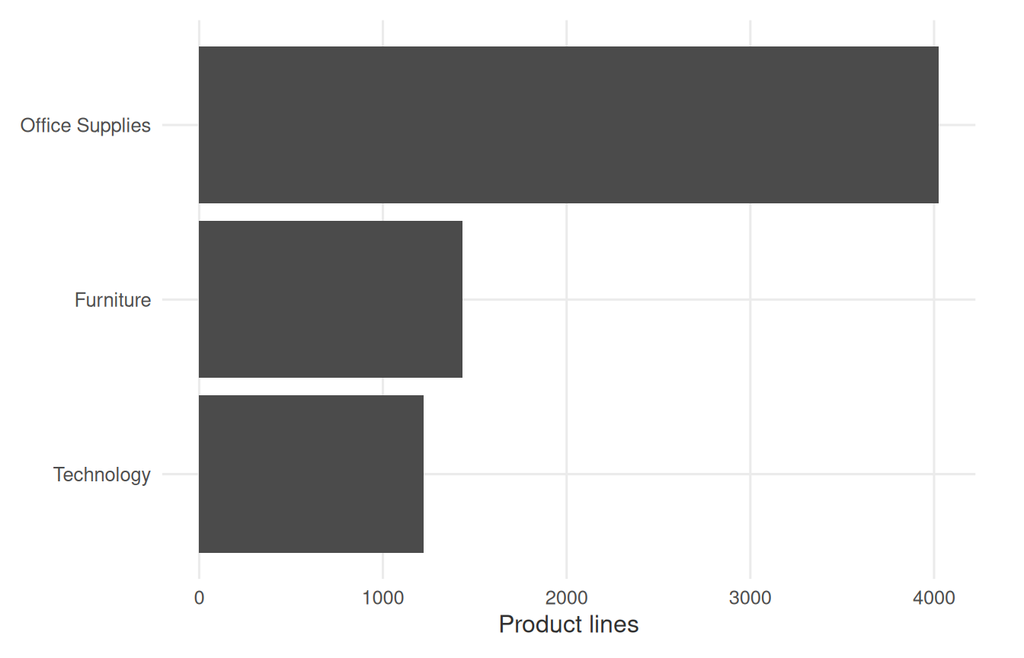

```r
ggplot(category_mix, aes(reorder(category, line_count), line_count)) +
  geom_col(fill = petra_ink) + coord_flip() +
  labs(x = NULL, y = "Product lines")
```

- `count()` produces frequencies.
- The denominator is all product lines in the extract.
- Office Supplies dominates line count; this does not establish the largest revenue or profit contribution.
- Categories have no required numerical order, so a cumulative category percentage would depend on an arbitrary arrangement.

### Change the business measure

```r
category_sales <- lines %>% group_by(category) %>%
  summarise(total_sales = sum(sales), total_units = sum(quantity), .groups = "drop") %>%
  mutate(sales_pct = 100 * total_sales / sum(total_sales))
knitr::kable(category_sales, digits = 1)
```

| category | total_sales | total_units | sales_pct |
| --- | --- | --- | --- |
| Furniture | 526612.5 | 5591 | 33.7 |
| Office Supplies | 472949.9 | 15230 | 30.2 |
| Technology | 564423.2 | 4576 | 36.1 |

- A line can contain several units and very different sales values.
- Line share, unit share and revenue share answer different questions.
- Technology leads revenue here even though it has fewer lines than Office Supplies.

**Pause:** Which measure would you use to discuss warehouse picking activity? Which would you use to discuss revenue? Explain the limits of each.

## 4. Compare customer segments

```r
counts <- xtabs(~ segment + category, data = lines)
row_percent <- 100 * prop.table(counts, margin = 1)
knitr::kable(counts)
```

|  | Furniture | Office Supplies | Technology |
| --- | --- | --- | --- |
| Consumer | 761 | 2106 | 656 |
| Corporate | 448 | 1229 | 363 |
| Home Office | 226 | 689 | 204 |

```r
knitr::kable(row_percent, digits = 1)
```

|  | Furniture | Office Supplies | Technology |
| --- | --- | --- | --- |
| Consumer | 21.6 | 59.8 | 18.6 |
| Corporate | 22.0 | 60.2 | 17.8 |
| Home Office | 20.2 | 61.6 | 18.2 |

- Rows: customer segments.
- Columns: product categories.
- Each percentage row totals 100%.
- A cell answers: “Within this segment’s product lines, what percentage belong to this category?”
- Dividing by a column total answers a different question: segment mix within a category.

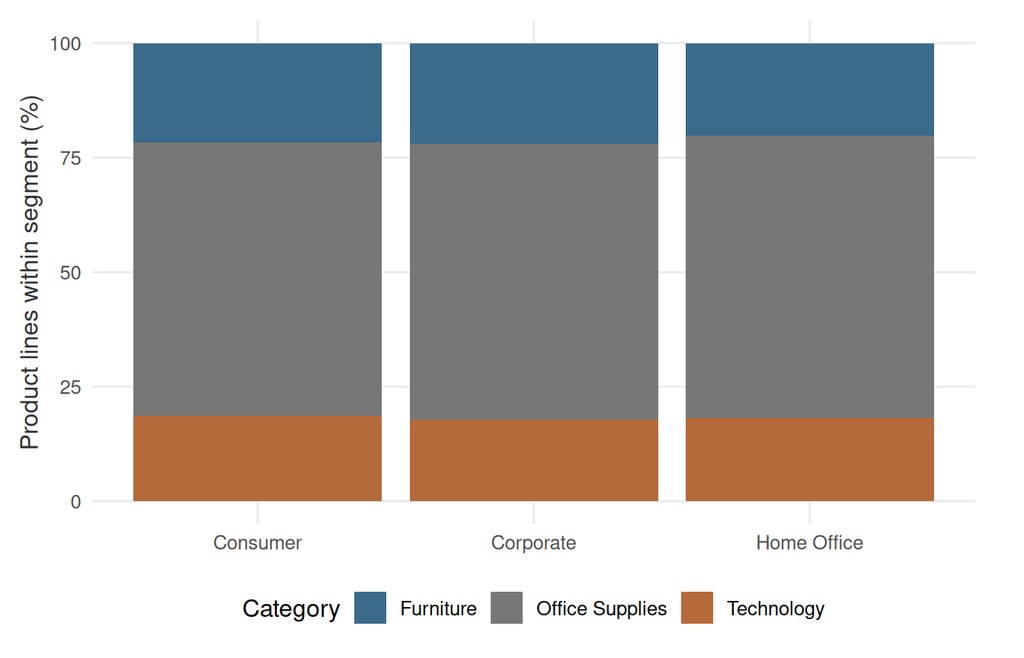

```r
plot_mix <- lines %>% count(segment, category) %>%
  group_by(segment) %>% mutate(percent = 100 * n / sum(n)) %>% ungroup()
ggplot(plot_mix, aes(segment, percent, fill = category)) +
  geom_col() + scale_fill_manual(values = petra_categories) +
  labs(x = NULL, y = "Product lines within segment (%)", fill = "Category")
```

- Every segment bar reaches 100%, even though segment counts differ.
- State both percentages and denominators when reporting a comparison.
- A difference of 5 percentage points is not automatically a 5% relative increase.

## 5. Use an ordered cumulative summary

> What share of orders is dispatched within each number of days?

```r
shipping <- orders %>% count(ship_days, name = "order_count") %>%
  arrange(ship_days) %>%
  mutate(percent = 100 * order_count / sum(order_count), cumulative_pct = cumsum(percent))
knitr::kable(shipping, digits = 1)
```

| ship_days | order_count | percent | cumulative_pct |
| --- | --- | --- | --- |
| 0 | 168 | 5.1 | 5.1 |
| 1 | 111 | 3.3 | 8.4 |
| 2 | 456 | 13.7 | 22.1 |
| 3 | 319 | 9.6 | 31.7 |
| 4 | 935 | 28.1 | 59.9 |
| 5 | 741 | 22.3 | 82.2 |
| 6 | 396 | 11.9 | 94.1 |
| 7 | 196 | 5.9 | 100.0 |

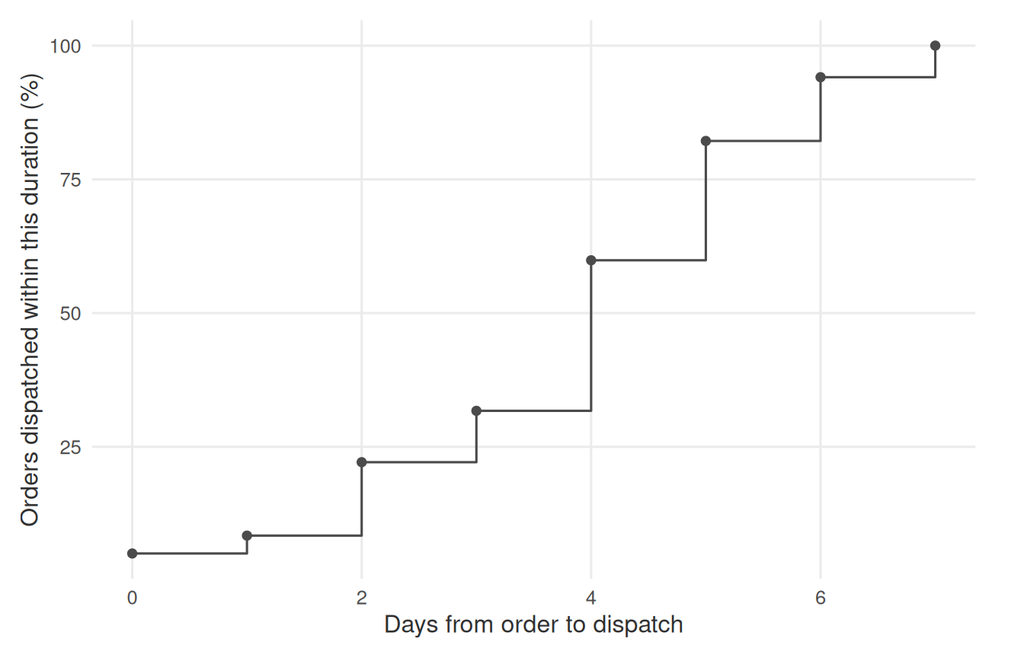

```r
ggplot(shipping, aes(ship_days, cumulative_pct)) +
  geom_step(colour = petra_ink) + geom_point(colour = petra_ink) +
  labs(x = "Days from order to dispatch", y = "Orders dispatched within this duration (%)")
```

- Durations have a natural order, so cumulative percentages are meaningful.
- Use one record per order; counting lines would give large baskets extra weight.
- Dispatch time is not delivery time.
- Observed lag is not the same as an advertised service guarantee.

## 6. Interpret a returns table correctly

```r
return_mix <- orders %>% count(return_status, name = "order_count") %>%
  mutate(percent = 100 * order_count / sum(order_count))
knitr::kable(return_mix, digits = 2)
```

| return_status | order_count | percent |
| --- | --- | --- |
| Listed return | 191 | 5.75 |
| Not listed | 3131 | 94.25 |

- An order is **Listed return** when its ID appears in the workbook’s Returns sheet.
- The unit and denominator are orders, not products, returned units or customers.
- **Not listed** is absence from this source table; it is not independently confirmed non-return.
- Do not use the table to infer refund amounts or to adjust recorded profit.

## 7. Independent business briefing

The regional manager asks for a one-page summary.

1. Build a region frequency table using **orders**, with percentages.
2. Compare shipping-mode percentages **within each region**.
3. Show one chart that makes this comparison readable.
4. Calculate the percentage dispatched within four days, overall and by region.
5. Report the listed-return percentage for each segment, using orders.
6. Write four bullets: finding, numerical evidence, denominator and limitation.

```r
# Use orders for these questions.
# Start with count(region), then xtabs(~ region + ship_mode, data = orders).
# For a group proportion: mean(ship_days <= 4) within each region.
```

**Check your reasoning:**

- Would line-based results give every order equal weight?
- Are you interpreting dispatch rather than delivery?
- Does the reader know whether a percentage is within a row or within the full table?

## 8. Continue

- Keep your tables and briefing in your Positron workspace.
- Continue to Practical 2: Order size.
- Source definitions and extract limits: `data/business/README.md`.